# Intro to Data Science HW 8

## Part 5: Now build a tree model (with rpart)

A. Build a model with rpart  
Note: you might need to install the e1071 package

```r
Rpart_Model <- train(credit_risk ~ ., data=trainSet, method="rpart",
                           preProc=c("center", "scale"))
```

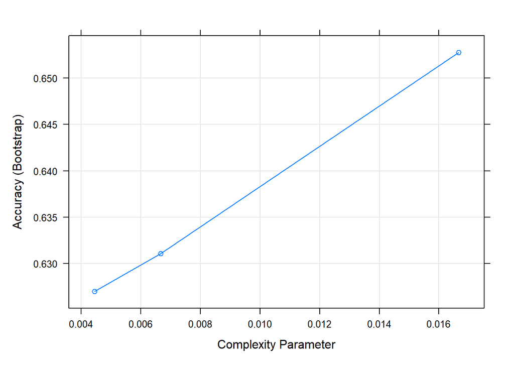

```r
# install.packages("rpart.plot")
library(rpart.plot)
plot(Rpart_Model)
```

C. Use the **predict()** function to predict the testData, and then generate a confusion matrix to explore the results

```r
rpartPred <- predict(Rpart_Model, newData=testSet, type="raw")
cf2 <- confusionMatrix(rpartPred, testSet$credit_risk)
cf2
```

```
## Confusion Matrix and Statistics
##
##           Reference
## Prediction   0   1
##          0   0   0
##          1 150 350
##
##                Accuracy : 0.7
##                  95% CI : (0.6577, 0.7399)
##     No Information Rate : 0.7
##     P-Value [Acc > NIR] : 0.522
##
##                   Kappa : 0
##
##  Mcnemar's Test P-Value : <2e-16
##
##             Sensitivity : 0.0
##             Specificity : 1.0
##          Pos Pred Value : NaN
##          Neg Pred Value : 0.7
##              Prevalence : 0.3
##          Detection Rate : 0.0
##    Detection Prevalence : 0.0
##       Balanced Accuracy : 0.5
##
##        'Positive' Class : 0
##
```

D. Review the attributes being used for this credit decision. Are there any that might not be appropriate, with respect to fairness? If so, which attribute, and how would you address this fairness situation. Answer in a comment block below

```r
# One attribute being used to train the model which could lead to biased results is Age. The model may discriminate against
# applicants based on age, for example, denying loans to people who are younger. One way to mitigate this issue is to remove
# age from the training features and instead use features like credit history. If a person has good credit, good credit age,
# a history of making payments on time, keeping low credit utilization, etc., then the person's age does not need to be taken
# into account when deciding on granting them a loan.
glimpse(cred)
```

```
## Rows: 1,000
## Columns: 8
## $ duration          <int> 6, 48, 12, 42, 24, 36, 24, 36, 12, 30, 12, 48, 12, 2…
## $ amount            <int> 1169, 5951, 2096, 7882, 4870, 9055, 2835, 6948, 3059…
## $ installment_rate  <int> 4, 2, 2, 2, 3, 2, 3, 2, 2, 4, 3, 3, 1, 4, 2, 4, 4, 2…
## $ present_residence <int> 4, 2, 3, 4, 4, 4, 4, 2, 4, 2, 1, 4, 1, 4, 4, 2, 4, 3…
## $ age               <int> 67, 22, 49, 45, 53, 35, 53, 35, 61, 28, 25, 24, 22, …
## $ credit_history    <int> 2, 1, 1, 1, 2, 1, 1, 1, 1, 2, 1, 1, 1, 2, 1, 1, 2, 3…
## $ people_liable     <int> 1, 1, 2, 2, 2, 2, 1, 1, 1, 1, 1, 1, 1, 1, 1, 1, 1, 1…
## $ credit_risk       <fct> 1, 0, 1, 1, 0, 1, 1, 1, 1, 0, 0, 0, 1, 0, 1, 0, 1, 1…
```